# HCA Analysis

Kaila Velasco

2023-10-11

# Setup

```r
data <- read.csv("fish4.csv")
row.names(data) <- data$Fish
data[1] <- NULL
data
```

```
##            X25   X26 X26.5 X27.5   X29 X29.5   X30 X30.5   X32   X33 X34.5
## Shark     TRUE FALSE  TRUE FALSE  TRUE FALSE FALSE FALSE FALSE FALSE FALSE
## Salmon   FALSE  TRUE FALSE  TRUE  TRUE FALSE FALSE FALSE  TRUE FALSE  TRUE
## Trout    FALSE  TRUE FALSE  TRUE  TRUE  TRUE FALSE FALSE  TRUE FALSE  TRUE
## Catfish  FALSE  TRUE FALSE  TRUE  TRUE FALSE FALSE FALSE  TRUE FALSE FALSE
## Sturgeon FALSE  TRUE FALSE  TRUE FALSE FALSE  TRUE  TRUE FALSE  TRUE FALSE
##          X35.5   X36 X36.5   X37 X37.5   X38 X38.5   X39 X40.5   X41   X42
## Shark    FALSE  TRUE  TRUE FALSE FALSE FALSE FALSE  TRUE FALSE FALSE FALSE
## Salmon   FALSE FALSE  TRUE FALSE  TRUE FALSE FALSE FALSE  TRUE FALSE FALSE
## Trout    FALSE FALSE  TRUE FALSE  TRUE FALSE FALSE FALSE  TRUE FALSE  TRUE
## Catfish  FALSE FALSE  TRUE FALSE FALSE  TRUE  TRUE FALSE FALSE  TRUE FALSE
## Sturgeon  TRUE FALSE FALSE  TRUE FALSE FALSE FALSE  TRUE FALSE FALSE  TRUE
##          X42.5   X44   X45   X46 X46.5   X47 X47.5 X51.5   X52
## Shark    FALSE  TRUE FALSE FALSE FALSE FALSE FALSE FALSE  TRUE
## Salmon    TRUE FALSE  TRUE FALSE FALSE FALSE FALSE FALSE FALSE
## Trout    FALSE FALSE  TRUE FALSE  TRUE FALSE FALSE  TRUE FALSE
## Catfish  FALSE FALSE FALSE  TRUE FALSE FALSE  TRUE FALSE FALSE
## Sturgeon FALSE  TRUE FALSE FALSE FALSE  TRUE FALSE FALSE FALSE
```

```r
distance_measure <- dist(data, method = 'binary')
distance_measure
```

```
##              Shark    Salmon     Trout   Catfish
## Salmon   0.8750000
## Trout    0.8947368 0.3571429
## Catfish  0.8750000 0.6666667 0.7222222
## Sturgeon 0.8823529 0.8947368 0.8571429 0.8947368
```

# Hands-On Outputs

## Output 1

**Bring out the documentation for the `dist` command. What acceptable values can the `method` argument take?**

The `method` argument for `dist()` can accept the values `euclidean`, `maximum`, `manhattan`, `canberra`, `binary`, or `minkowski`.

## Output 2

**Prepare dendrograms using `single` and `average` linkage rules.**

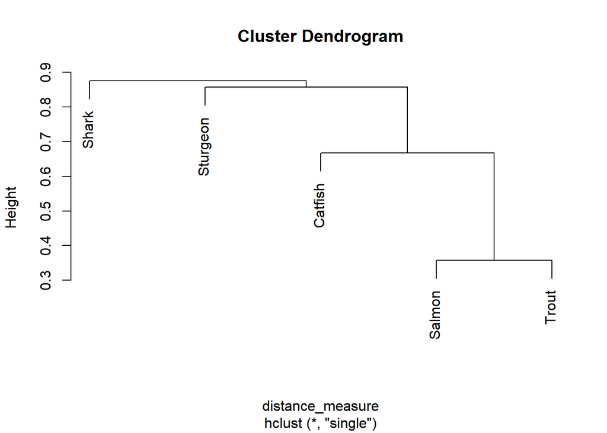

```r
plot(hclust(distance_measure, method = 'single'))
```

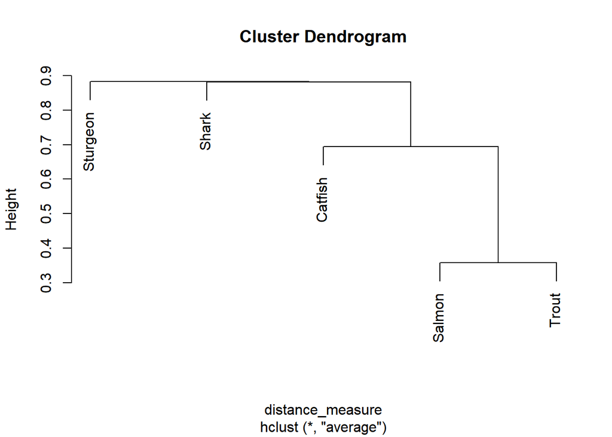

```r
plot(hclust(distance_measure, method = 'average'))
```

# Exercises

## Exercise 1

**The clustering approach that was performed in this activity is referred to as *agglomerative*. Differentiate it with another approach called *divisive*.**

“Agglomerative” clustering is “bottom-up.” Items are all sorted as individual entities, and then they are merged together to form the clusters. In contrast, “divisive” clustering is considered “top-down” and involves one big group that is split up into clusters as part of the clustering process.

## Exercise 2

**Compare and contrast HCA from K-means clustering.**

As indicated by the name, they are both methods of sorting data.

K-means clustering involves specifying a set number of clusters, and allowing the algorithm to sort entries into the clusters based on the provided parameters.

HCA however requires a method. The final number of clusters varies in the end, based on the method which was chosen in the first place.

## Exercise 3

**Perform HCA on the iris dataset. Compare the results with k-means clustering (which you performed in the past activity). For this dataset, which do you think is a better method to group data?**

### HCA

The procedure for constructing an HCA for the iris dataset is as follows:

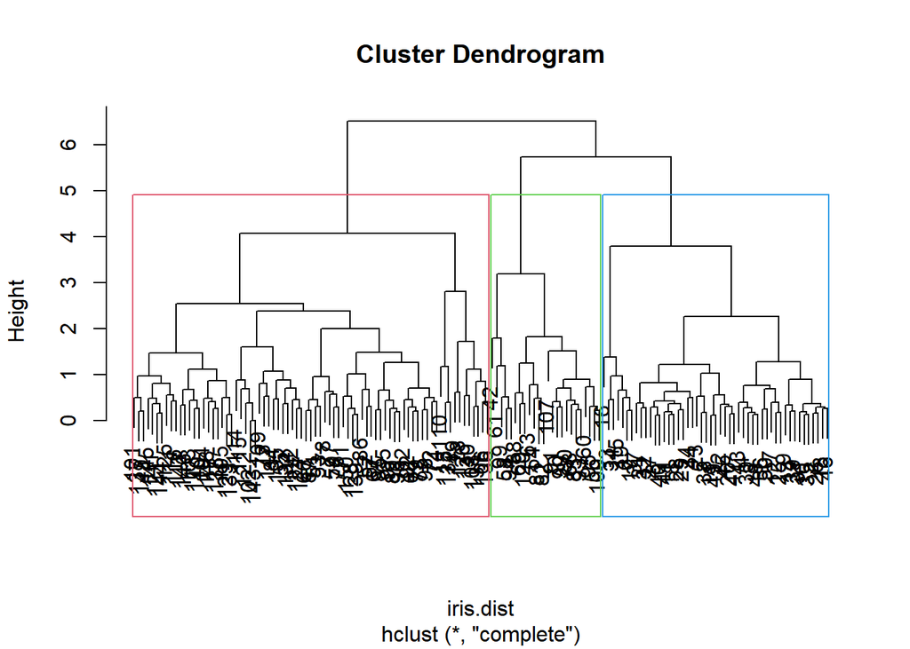

```r
iris_data <- iris[1:4]
iris_data_std <- scale(iris_data)
iris.dist <- dist(iris_data_std)
hc.out_iris <- hclust(iris.dist, method = "complete")
plot(hc.out_iris)
rect.hclust(hc.out_iris, k = 3, border = 2:5)
```

### K-means

Now, I will quickly perform a K-means clustering of the dataset. I will not go into too much detail for the sake of my own sanity.

```r
set.seed(1234)
library(factoextra)
```

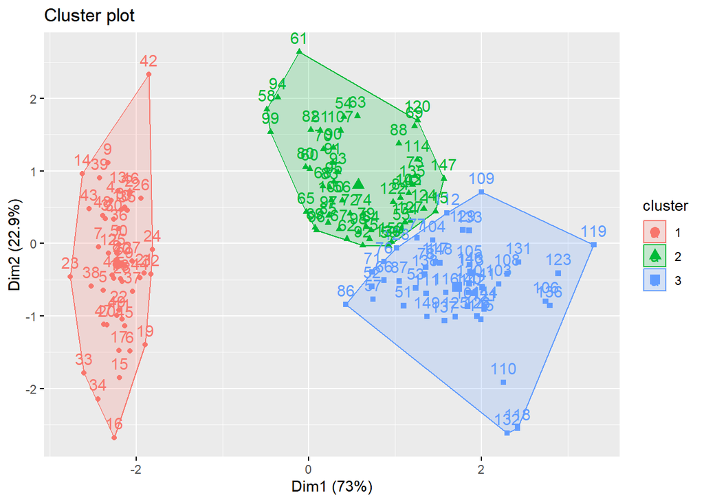

```r
sc_df <- scale(iris[1:4], center = T, scale = T)
clust <- kmeans(sc_df, centers = 3, n = 50)
fviz_cluster(clust, data = sc_df)
```